# Курсова работа по "Интелигентни системи"

**Тема:** Diabetes Prediction (Binary Classification)

**Изготвил:**  
124151, Емине Юмер, гр. 34

```python
import pandas as pd
import numpy as np
import matplotlib.pyplot as plt
import seaborn as sns
%matplotlib inline

from sklearn.model_selection import train_test_split
from sklearn.linear_model import LogisticRegression
from sklearn.tree import DecisionTreeClassifier
from sklearn.ensemble import RandomForestClassifier
from sklearn.metrics import classification_report, confusion_matrix, roc_auc_score, roc_curve

import shap
shap.initjs()
import warnings
warnings.filterwarnings('ignore')

sns.set_theme(style='whitegrid', palette='husl')
RANDOM_STATE = 42
```

## 1. Описание на данните

Използваният набор от данни е `diabetes_prediction_dataset.csv`, извлечен от Kaggle (https://www.kaggle.com/datasets/iammustafatz/diabetes-prediction-dataset). Съдържа демографски и медицински показатели, които могат да бъдат използвани за предсказване на целевата променлива `diabetes`:

- `0` - пациентът няма диабет
- `1` - пациентът има диабет

В анализа ще обърнем внимание на:

1. структурата и типовете данни;
2. описателната статистика;
3. разпределението на целевата променлива;
4. кои признаци изглеждат най-силно свързани с диабета.

```python
data = pd.read_csv("diabetes_prediction_dataset.csv")
data.head()
```

|  | gender | age | hypertension | heart_disease | smoking_history | bmi | HbA1c_level | blood_glucose_level | diabetes |
| --- | --- | --- | --- | --- | --- | --- | --- | --- | --- |
| 0 | Female | 80.0 | 0 | 1 | never | 25.19 | 6.6 | 140 | 0 |
| 1 | Female | 54.0 | 0 | 0 | No Info | 27.32 | 6.6 | 80 | 0 |
| 2 | Male | 28.0 | 0 | 0 | never | 27.32 | 5.7 | 158 | 0 |
| 3 | Female | 36.0 | 0 | 0 | current | 23.45 | 5.0 | 155 | 0 |
| 4 | Male | 76.0 | 1 | 1 | current | 20.14 | 4.8 | 155 | 0 |

```python
data.info()
```

```
<class 'pandas.core.frame.DataFrame'>
RangeIndex: 100000 entries, 0 to 99999
Data columns (total 9 columns):
 #   Column               Non-Null Count   Dtype
---  ------               --------------   -----
 0   gender               100000 non-null  object
 1   age                  100000 non-null  float64
 2   hypertension         100000 non-null  int64
 3   heart_disease        100000 non-null  int64
 4   smoking_history      100000 non-null  object
 5   bmi                  100000 non-null  float64
 6   HbA1c_level          100000 non-null  float64
 7   blood_glucose_level  100000 non-null  int64
 8   diabetes             100000 non-null  int64
dtypes: float64(3), int64(4), object(2)
memory usage: 6.9+ MB
```

```python
data.describe()
```

|  | age | hypertension | heart_disease | bmi | HbA1c_level | blood_glucose_level | diabetes |
| --- | --- | --- | --- | --- | --- | --- | --- |
| count | 100000.000000 | 100000.00000 | 100000.000000 | 100000.000000 | 100000.000000 | 100000.000000 | 100000.000000 |
| mean | 41.885856 | 0.07485 | 0.039420 | 27.320767 | 5.527507 | 138.058060 | 0.085000 |
| std | 22.516840 | 0.26315 | 0.194593 | 6.636783 | 1.070672 | 40.708136 | 0.278883 |
| min | 0.080000 | 0.00000 | 0.000000 | 10.010000 | 3.500000 | 80.000000 | 0.000000 |
| 25% | 24.000000 | 0.00000 | 0.000000 | 23.630000 | 4.800000 | 100.000000 | 0.000000 |
| 50% | 43.000000 | 0.00000 | 0.000000 | 27.320000 | 5.800000 | 140.000000 | 0.000000 |
| 75% | 60.000000 | 0.00000 | 0.000000 | 29.580000 | 6.200000 | 159.000000 | 0.000000 |
| max | 80.000000 | 1.00000 | 1.000000 | 95.690000 | 9.000000 | 300.000000 | 1.000000 |

```python
data.describe(include='object')
```

|  | gender | smoking_history |
| --- | --- | --- |
| count | 100000 | 100000 |
| unique | 3 | 6 |
| top | Female | No Info |
| freq | 58552 | 35816 |

## 2. Липсващи стойности

В набора от данни няма липсващи стойности. Това ни позволява да преминем директно към предварителния анализ и подготовката на данните, без да правим импутация или премахване на записи.

```python
missing = pd.DataFrame({
    'Missing values count': data.isnull().sum(),
    'Missing values %': data.isnull().sum() / data.shape[0] * 100
}).round(2)

missing.style.format({'Missing values %': '{:.2f}%'})
```

|  | Missing values count | Missing values % |
| --- | --- | --- |
| gender | 0 | 0.00% |
| age | 0 | 0.00% |
| hypertension | 0 | 0.00% |
| heart_disease | 0 | 0.00% |
| smoking_history | 0 | 0.00% |
| bmi | 0 | 0.00% |
| HbA1c_level | 0 | 0.00% |
| blood_glucose_level | 0 | 0.00% |
| diabetes | 0 | 0.00% |

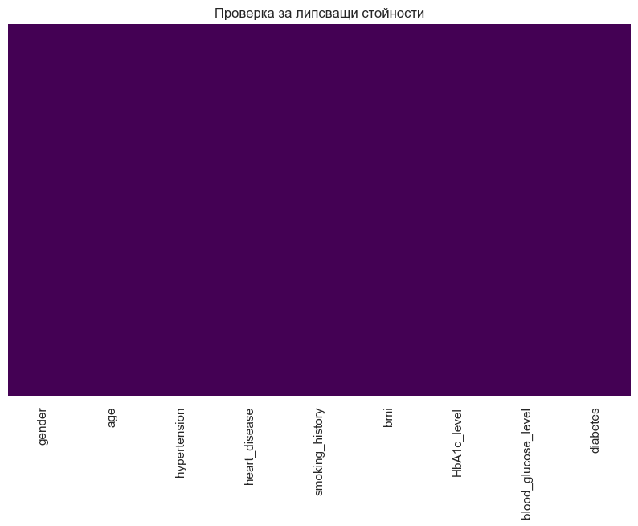

```python
plt.figure(figsize=(10, 6))
sns.heatmap(data.isnull(), yticklabels=False, cbar=False, cmap='viridis')
plt.title('Проверка за липсващи стойности')
plt.show()
```

## 3. Предварителен анализ на данните (EDA)

Разпределение признаците и каква е връзката им с целевата променлива `diabetes`.

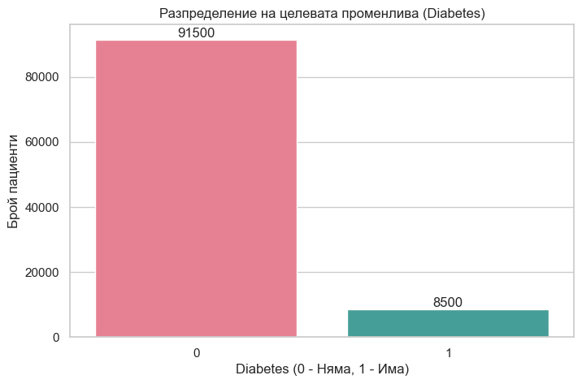

```python
plt.figure(figsize=(8, 5))
g = sns.countplot(data=data, x='diabetes', palette='husl')
for i in g.containers:
    g.bar_label(i)

plt.title('Разпределение на целевата променлива (Diabetes)')
plt.xlabel('Diabetes (0 - Няма, 1 - Има)')
plt.ylabel('Брой пациенти')
plt.show()
```

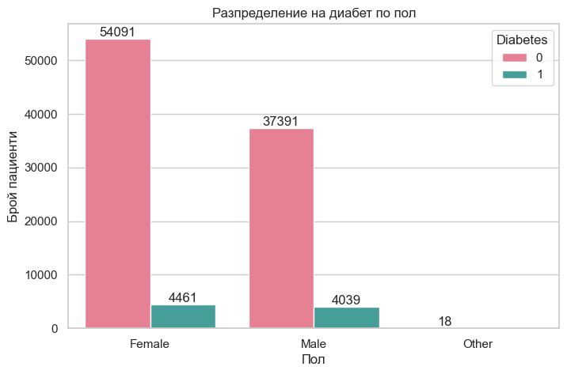

```python
plt.figure(figsize=(8, 5))
g = sns.countplot(data=data, x='gender', hue='diabetes', palette='husl')
for i in g.containers:
    g.bar_label(i)

plt.title('Разпределение на диабет по пол')
plt.xlabel('Пол')
plt.ylabel('Брой пациенти')
plt.legend(title='Diabetes')
plt.show()
```

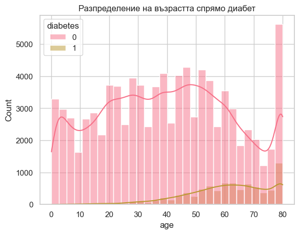

```python
sns.histplot(data=data, x='age', hue='diabetes', kde=True, bins=30)
plt.title('Разпределение на възрастта спрямо диабет')
plt.show()
```

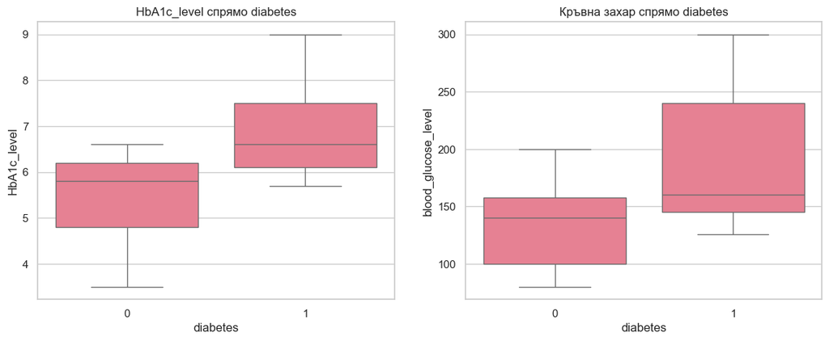

```python
fig, axes = plt.subplots(1, 2, figsize=(14,5))
sns.boxplot(data=data, x='diabetes', y='HbA1c_level', ax=axes[0])
sns.boxplot(data=data, x='diabetes', y='blood_glucose_level', ax=axes[1])
axes[0].set_title('HbA1c_level спрямо diabetes')
axes[1].set_title('Кръвна захар спрямо diabetes')
plt.show()
```

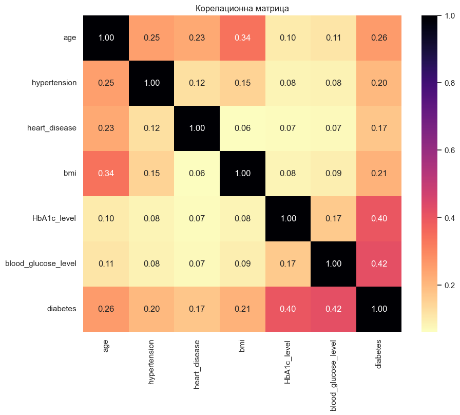

```python
plt.figure(figsize=(10,8))
sns.heatmap(data.corr(numeric_only=True), annot=True, cmap='magma_r', fmt='.2f')
plt.title('Корелационна матрица')
plt.show()
```

```python
summary = (
    data.groupby("diabetes")[["age", "bmi", "HbA1c_level", "blood_glucose_level"]]
    .mean()
    .round(2)
)
summary
```

| diabetes | age | bmi | HbA1c_level | blood_glucose_level |
| --- | --- | --- | --- | --- |
| 0 | 40.12 | 26.89 | 5.40 | 132.85 |
| 1 | 60.95 | 31.99 | 6.93 | 194.09 |

**Изводи от EDA:**  
От визуализациите се вижда, че пациентите с диабет средно са по-възрастни и имат по-високи стойности на `HbA1c_level` и `blood_glucose_level`. При `bmi` също се наблюдава тенденция към по-високи стойности за хората с диабет. Това подсказва, че именно тези признаци вероятно ще бъдат сред най-важните за моделите.

## 4. Подготовка на данните за обучение

Използваме `stratify=y`, за да запазим приблизително същото разпределение на класовете в train и test множеството.

```python
data_encoded = pd.get_dummies(data, columns=['gender', 'smoking_history'], drop_first=True)

X = data_encoded.drop('diabetes', axis=1)
y = data_encoded['diabetes']

X_train, X_test, y_train, y_test = train_test_split(
    X, y, test_size=0.25, random_state=RANDOM_STATE, stratify=y
)
```

След трансформацията всички признаци са в числов вид и могат да бъдат използвани директно от алгоритмите за машинно обучение.

## 5. Обучение на моделите

Ще обучим няколко различни алгоритъма:

```python
models = {
    'Logistic Regression': LogisticRegression(max_iter=1000, class_weight='balanced', random_state=RANDOM_STATE),
    'Decision Tree': DecisionTreeClassifier(max_depth=6, class_weight='balanced', random_state=RANDOM_STATE),
    'Random Forest': RandomForestClassifier(n_estimators=150, max_depth=8, class_weight='balanced', random_state=RANDOM_STATE)
}

predictions = {}
probabilities = {}

for name, model in models.items():
    model.fit(X_train, y_train)
    pred = model.predict(X_test)
    proba = model.predict_proba(X_test)[:, 1]

    predictions[name] = pred
    probabilities[name] = proba

    print (name)
    print(classification_report(y_test, pred))
```

```
Logistic Regression
              precision    recall  f1-score   support

           0       0.99      0.89      0.94     22875
           1       0.43      0.89      0.58      2125

    accuracy                           0.89     25000
   macro avg       0.71      0.89      0.76     25000
weighted avg       0.94      0.89      0.91     25000

Decision Tree
              precision    recall  f1-score   support

           0       0.99      0.85      0.92     22875
           1       0.37      0.93      0.53      2125

    accuracy                           0.86     25000
   macro avg       0.68      0.89      0.72     25000
weighted avg       0.94      0.86      0.88     25000

Random Forest
              precision    recall  f1-score   support

           0       0.99      0.92      0.95     22875
           1       0.51      0.89      0.65      2125

    accuracy                           0.92     25000
   macro avg       0.75      0.90      0.80     25000
weighted avg       0.95      0.92      0.93     25000
```

За сравнение използваме няколко метрики, защото само `accuracy` не е достатъчна при небалансирани класове. По-важни тук са `recall`, `F1-score` и `ROC-AUC`.

## 6. Оценка на моделите

В тази секция ще:

- сравним моделите по основни метрики;
- визуализираме `ROC` кривите;
- покажем `classification report` и `confusion matrix` за най-добрия модел.

```python
best_model_name = max(probabilities, key=lambda x: roc_auc_score(y_test, probabilities[x]))
print(f"Най-добър модел: {best_model_name}")
```

```
Най-добър модел: Random Forest
```

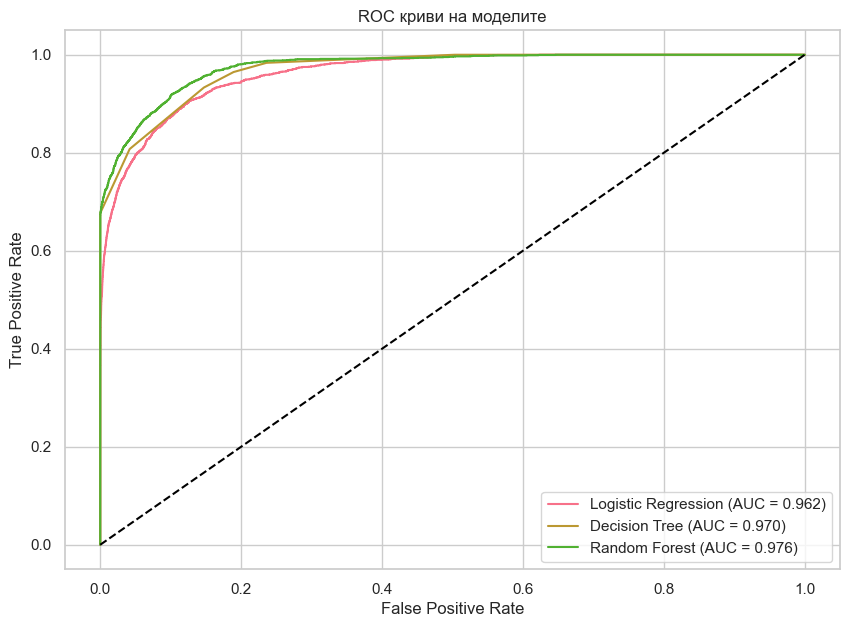

```python
plt.figure(figsize=(10,7))
for name, proba in probabilities.items():
    fpr, tpr, _ = roc_curve(y_test, proba)
    auc = roc_auc_score(y_test, proba)
    plt.plot(fpr, tpr, label=f'{name} (AUC = {auc:.3f})')

plt.plot([0,1],[0,1], 'k--')
plt.title('ROC криви на моделите')
plt.xlabel('False Positive Rate')
plt.ylabel('True Positive Rate')
plt.legend()
plt.show()
```

```
              precision    recall  f1-score   support

           0       0.99      0.92      0.95     22875
           1       0.51      0.89      0.65      2125

    accuracy                           0.92     25000
   macro avg       0.75      0.90      0.80     25000
weighted avg       0.95      0.92      0.93     25000
```

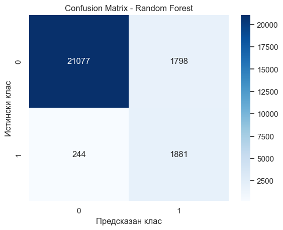

```python
print(classification_report(y_test, predictions[best_model_name]))

cm = confusion_matrix(y_test, predictions[best_model_name])
sns.heatmap(cm, annot=True, fmt='d', cmap='Blues')
plt.title(f'Confusion Matrix - {best_model_name}')
plt.xlabel('Предсказан клас')
plt.ylabel('Истински клас')
plt.show()
```

**Извод:**  
Най-добрият модел е този, който успява да постигне най-добър баланс между откриване на положителните случаи и ограничаване на грешните аларми. При медицински задачи `recall` е особено важна метрика, защото пропускането на пациент с диабет би било по-рисково от маркирането на допълнителен случай за проверка.

## 7. Интерпретиране на моделите

Ще интерпретираме най-добрия модел по два начина:

1. чрез важност на признаците (`feature importance`);
2. чрез `SHAP`, който показва приноса на всеки признак към прогнозата.

```python
rf_model = models['Random Forest']
```

```python
importances = pd.Series(
    rf_model.feature_importances_,
    index=X.columns
).sort_values(ascending=False).head(12)
```

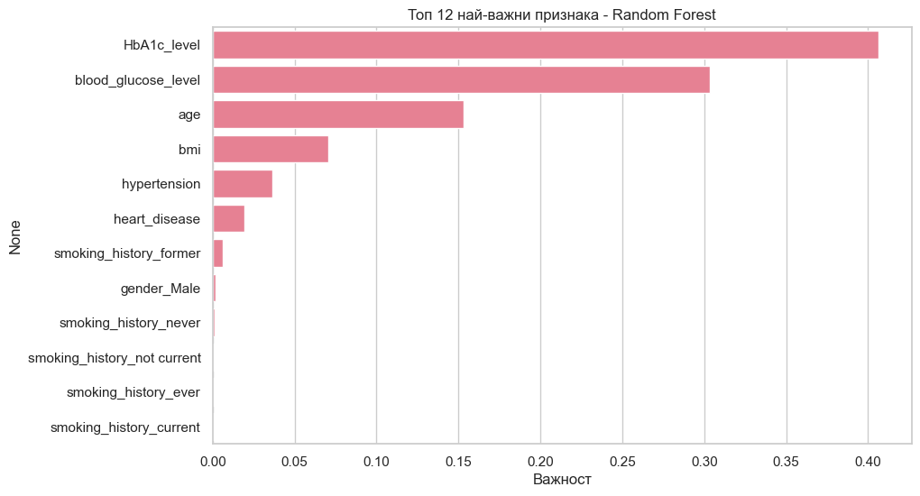

```python
plt.figure(figsize=(10, 6))
sns.barplot(x=importances.values, y=importances.index)
plt.title('Топ 12 най-важни признака - Random Forest')
plt.xlabel('Важност')
plt.show()
```

```python
X_sample = X_test.iloc[:800]
explainer = shap.TreeExplainer(rf_model)
shap_values = explainer.shap_values(X_sample)
```

```python
print("shap_values:", shap_values[1].shape)
print("X_sample:", X_sample.shape)
```

```
shap_values: (13, 2)
X_sample: (800, 13)
```

[figure not shown]

```python
shap.summary_plot(
    shap_values[1],
    feature_names=X.columns.tolist(),
    plot_type="bar",
    max_display=12
)
```

[figure not shown]

```python
shap.summary_plot(
    shap_values[1],
    feature_names=X.columns.tolist(),
    max_display=12
)
```

## 8. Обяснение на индивидуални прогнози

Според указанията трябва да покажем поне две индивидуални прогнози:

- една положителна прогноза;
- една отрицателна прогноза.

За целта ще използваме `SHAP waterfall plot`, който показва как отделните признаци изместват прогнозата към клас `1` или към клас `0`.

```python
import numpy as np
```

```python
pred_sample = rf_model.predict(X_sample)
y_sample = y_test.loc[X_sample.index]
```

```python
positive_idx = np.where(pred_sample == 1)[0][0]
negative_idx = np.where(pred_sample == 0)[0][0]
```

```python
print('Positive prediction index:', positive_idx)
print('Negative prediction index:', negative_idx)
```

```
Positive prediction index: 4
Negative prediction index: 0
```

```python
positive_explanation = shap.Explanation(
    values=shap_values[1][positive_idx],
    base_values=explainer.expected_value[1],
    data=X_sample.iloc[positive_idx],
    feature_names=X.columns.tolist()
)
```

```
Positive prediction:
Actual class: 0
Predicted class: 1
```

[figure not shown]

```python
print('\nPositive prediction:')
print('Actual class:', y_sample.iloc[positive_idx])
print('Predicted class:', pred_sample[positive_idx])
shap.plots.waterfall(positive_explanation, max_display=12)
```

```python
negative_explanation = shap.Explanation(
    values=shap_values[1][negative_idx],
    base_values=explainer.expected_value[1],
    data=X_sample.iloc[negative_idx],
    feature_names=X.columns.tolist()
)
```

```
Negative prediction:
Actual class: 0
Predicted class: 0
```

[figure not shown]

```python
print('\nNegative prediction:')
print('Actual class:', y_sample.iloc[negative_idx])
print('Predicted class:', pred_sample[negative_idx])
shap.plots.waterfall(negative_explanation, max_display=12)
```

## Заключение

В тази курсова работа беше реализирана задача по бинарна класификация върху dataset за диабет. Бяха изпълнени всички основни етапи:

1. описание и проверка на данните;
2. предварителен анализ и визуализации;
3. подготовка на признаците;
4. обучение на няколко различни модела;
5. сравнение чрез подходящи метрики;
6. интерпретация чрез feature importance и SHAP;
7. обяснение на индивидуални прогнози.

Финалният извод е, че признаци като `HbA1c_level`, `blood_glucose_level`, `age` и `bmi` имат най-силен принос към прогнозите. Това е логично и от медицинска гледна точка, защото тези показатели са пряко свързани с риска от диабет.